# Inspección (Verificación)

En el control de calidad, para suministrar productos y servicios que cumplen con los requisitos del cliente, es necesario determinar y separar aquellos que satisfacen los requisitos de aquellos que no. Esta actividad se denomina inspección.

- El significado de la inspección y los tipos de inspección.
- Es significado de producto conforme (o apto) y no conforme (o defectuoso).
- El significado de lote aceptado y lote rechazado.

[Audio_1](https://drive.google.com/file/d/1IVQeuAcVL_09WHc3BBTEnTBvuO08cK1e/view?usp=drive_link)

```python
import os

try:
  os.chdir('../Python/QCKentei4')
except:
  pass

path = os.getcwd()
path
```

```
'/Users/takanohiroshi/Library/CloudStorage/OneDrive-個人用/Documenten/Python/QCKentei4'
```

```python
from PIL import Image
```

## 05-01 Inspección (Verificación)

検査とは

**Inspeccion**: 検査 Es la actividad de realizar mediciones o pruebas en productos o servicios y compararlas con los requisitos especificados en las exigencia del cliente o en las normas, para determinar si cumplen o no con dichos requisitos.

**Medición**: 計測 Es la actividad de investigar y aplicar métodos y medios de medición con un propósito específico, y utilizar los resultados para lograr el objetivo inicial.

Una función clave de la inspección es la **garantía de calidad**（品質保証）, que consiste en evitar que los productos no conformes lleguen a los clientes o a los procesos posteriores.

[Audio_2](https://drive.google.com/file/d/1oiKWOgkgQEmxXKql_QVR9Txsx0tvQXwo/view?usp=drive_link)

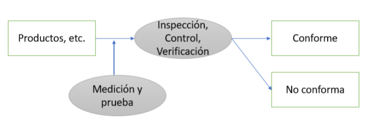

```python
img = Image.open('./Data4/Inspección.png')
display(img)
```

## 05-02 Conforme (Producto)

適合（品）、不適合（品）

**Conforme (Producto)**: 適合（品） Es el estado (o artículo) que, tras la inspección, satisface los requisitos especificados en las exigencias del cliente o en las normas.

**No conforme (Producto)**: 不適合（品） Es el estado (o artículo) que, tras la inspección, no satisface los requisitos especificados en las exigencias del cliente o en las normas.

[Audio_3](https://drive.google.com/file/d/1tEPyvsnk5wjAx-iV_rQNSxlSqNAQI1ue/view?usp=drive_link)

## 05-03 Aprobación/Rechazo de Lotes

ロットの合格・不合格

**Lotes**: ロット Se define como lote a una agrupación de articulos que han sido fabricados, o se presume que lo han sido, bajo las mismas condiciones.

### 1. Lotes

ロットとは

Por ejemplo, un grupo de 100 piezas de precisión producidas en la misma máquina en un solo día puede considerarse un solo lote, ya que comparten las mismas características: fueron fabricadas el mismo día, en la misma máquina y por el mismo operario.

El número de productos dentro de un solo lote se denomina **tamaño del lote**（ロットサイズ）.

Se puede pensar en los lotes también en el contexto de los servicios. Por ejemplo, en un centro de llamadas, el conjunto de consultas atendidas por un operador en un día determinado puede considerarse un lote.

### 2. Inspección de lotes / Control de lotes / Verificación de lotes

ロットに対する検査

Es frecuente que la inspección de lotes se realiza extrayendo una **muestra**（サンプル） del lote, realizando mediciones y pruebas sobre dicha muestra, y luego determinando si cumple con los criterios preestablecidos.

A este tipo de inspección se le llama **inspección por muestreo**（抜き取り検査）.

Además, la decisión se toma para el lote completo: si cumple con los criterios, se considera aprobado (o aceptado); si no, se considera rechazado.

Hay que tener en cuenta que, aunque las mediciones y pruebas se realizan sobre la muestra, la decisión de aprobación o rechazo se aplica al lote completo.

[Audio_4](https://drive.google.com/file/d/1SR6X-_zQIIRu_wpnT6O_MMJ_3hTjjMWM/view?usp=drive_link)

## 05-04 Tipos de inspección

検査の種類

### 1. Inspección en la etapa de fabricación / Control según el método / Verificación en la etapa de manufactura.

製造段階の検査

#### (1) Inspección en recepción / Inspección de entrada / Inspección de compra

受入検査・購入検査

#### (2) Inspección en proceso / Inspección intermedia / Inspección en proceso /Control en proceso / Control intermedio

工程内検査・中間検査

#### (3) Inspección final / Inspección de salida / Inspección de embarque / Control de salida / Control final / Control de embarque

最終検査・出荷検査

[Audio_5](https://drive.google.com/file/d/1NhmV33JMyBl7kb0DrRAWIe45BAkiRjMd/view?usp=drive_link)

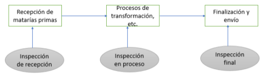

```python
img = Image.open('./Data4/Inspección_.png')
display(img)
```

### 2. Inspección por método / Control según el método / Verificación por método

方法別の検査

Entre los métodos de inspección se encuentran la inspección 100%, la inspección por muestreo y la inspección sin pruebas.

#### (1) Inspección 100%

全数検査

- Cuando no se permite incluir ni siquiera un solo producto no conforme / Cuando la inclusión de un solo producto no conformes es inaceptable
- Cuando está en en juesgo la vida humana / En casos que involucran vidas humanas.
- Cuando las pérdidas económicas son muy grandes / En caso de pérdidas económicas significativas.

#### (2) Inspección muestreo

抜き取り検査

La inspección en la que se determina si un lote completo es aceptado o rechazado basándose en una muestra tomada de él se denomina inspección por muestreo.

Dado que la inspección por muestreo no examina todos los productos de un lote, es posible que un lote aceptado aún contenga productos no conformes.

Por lo tanto, este método se aplica cuando el cliente acepta que pueda haber una cierta cantidad de productos no conformes en el envío.

#### (3) Inspección sin pruebas

無試験検査

La inspección que determina la conformidad basándose únicamente en la documentación presentada, sin realizar mediciones o pruebas, se denomina inspección sin pruebas.

### 3. Inspección por tipo de propiedad / Inspección según la naturaleza / Inspección por característica

性質別の検査

Entre los tipos de inspección según la naturaleza, se encuentran la inspección destructiva, la inspección no destructiva y la inspección sensorial

#### (1) Inspección destructiva

破壊検査

La inspección en la que el objeto de prueba es destruido, total o parcialmente, perdiendo su funcionalidad, se denomina inspección destructiva.

#### (2) Inspección no destructiva

非破壊検査

La inspección que se realiza sin destruir el objeto durante las mediciones o pruebas se denomina inspección no destructiva.

#### (3) Inspección sensorial

官能検査

La inspección que utiliza los cinco sentidos humanos (vista, oido, gusto, olfato y tacto) durante las mediciones o pruebas se denomina inspección sensorial o inspección organoléptica.

### 4. Inspección alternativa / Inspección de reemplazo

代用特性

La **inspección sustitutiva** (o alternativa) es otra característica de calidad que se utiliza como una evaluación equivalente o aproximada cuando resulta difícil medir directamente la característica de calidad requerida.

[Audio_6](https://drive.google.com/file/d/1e8JivV9kDMgXAnlz4FnwYuin625LELwn/view?usp=drive_link)

```python
notebook_name = 'QCKentei4-5.ipynb'
notebook_name_html = notebook_name.replace(".ipynb",".html")

!jupyter nbconvert --to html {notebook_name}
```

```
[NbConvertApp] Converting notebook QCKentei4-5.ipynb to html
[NbConvertApp] Writing 803709 bytes to QCKentei4-5.html
```

```python
from IPython.display import display
from PIL import Image
import gdown
import re

def get_file_id(url,out):
    # 正規表現でファイルIDを抽出
    match = re.search(r'/d/([a-zA-Z0-9_-]+)', url)

    if match:
        file_id = match.group(1)
        print("ファイルID:", file_id)
    else:
        print("ファイルIDが見つかりませんでした。")

    url = f"https://drive.google.com/uc?id={file_id}"

    output = out

    gdown.download(url, output, quiet=False)

    img = Image.open(out)
    display(img)
```

[output not shown]

[output not shown]

[figure not shown]

```python
url= 'https://drive.google.com/file/d/1PML969yrq2uAt_VqTGLRe5XMLmNDYseT/view?usp=drive_link'
out = './Data4/Inspección.png'
#get_file_id(url,out)
```

[output not shown]

[output not shown]

[figure not shown]

```python
url= 'https://drive.google.com/file/d/1z4F9glkHVi1X8jTe3ebux-IoNi7PPLfq/view?usp=drive_link'
out = './Data4/Inspección_.png'
#get_file_id(url,out)
```